# CALIDAD DE CONEXIÓN

# 7. EVALUACIÓN Y PRUEBAS DE HIPÓTESIS

### Hipótesis 1

En esta hipótesis se evaluará si es que la cantidad de personas dentro de un hogar que usan el WIFI es mayor o igual a 5, instalado por un proceedor, al mismo tiempo durante el día. Para ello usaremos la prueba de t-student, unilateral izquierda, con una significancia de α = 0.05, para analizar si es que nuestra hipótesis cumple y hallar su rechazo también.

H0 : La cantidad de personas que usan el WIFI de un hogar es mayor igual a 5.

H1 : La cantidad de personas que usan el WIFI de un hogar es menor a 5.

H0 : µ ≥5

H1 : µ < 5

```r
Base <- read.csv("CALIDADDECONEXION1.csv")
summary(Base$FAMILIARES_WIFI)
```

```
##    Min. 1st Qu.  Median    Mean 3rd Qu.    Max.
##   0.000   3.000   4.000   3.763   5.000  12.000
```

```r
sd(Base$FAMILIARES_WIFI)
```

```
## [1] 1.879611
```

```r
dim(Base)
```

```
## [1] 152  26
```

```r
qnorm(0.05)
```

```
## [1] -1.644854
```

Como nuestra muestra es de 152 personas encuestadas,o sea es mayor a 30, estaremos hallando y usando el z.

Z = -8.11

### Regiones Críticas

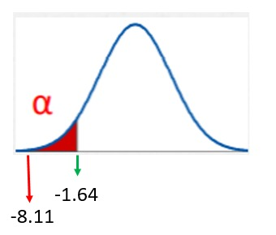

### Decisión

Como tenemos que Zcalc = -8.11 es menor a α = -1.64 deducimos que Z SI PERTENECE a la región sombreada, entonces SE RECHAZA H0.

### Hipótesis 2

En esta hipótesis estaremos indagando en la cantidad de fallas que presentan los clientes durante 4 semanas en su conectividad.Para ello usaremos la prueba de t-student, bilateral, con una significancia de α = 0.025, para analizar si es que nuestra hipótesis cumple y hallar su rechazo también.

H0 : La cantidad de fallas que presenta en 4 semanas es igual a 30.

H1 : La cantidad de fallas que presenta en 4 semanas es diferente a 30.

H0 : µ = 30

H1 : µ ≠ 30

```r
summary(Base$FALLAS_4_SEM)
```

```
##    Min. 1st Qu.  Median    Mean 3rd Qu.    Max.
##    1.00    5.00   12.00   15.95   30.00  120.00
```

```r
sd(Base$FALLAS_4_SEM)
```

```
## [1] 15.05062
```

```r
dim(Base)
```

```
## [1] 152  26
```

```r
qnorm(0.025)
```

```
## [1] -1.959964
```

Como nuestra muestra es de 152 personas encuestadas,o sea es mayor a 30, estaremos hallando y usando el z.

Z = -11.51

### Regiones Críticas

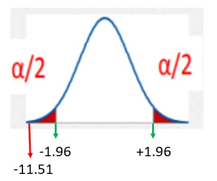

### Decisión

Como tenemos que Zcalc = -11.51 es menor a α = -1.96 deducimos que Z SI PERTENECE a la región sombreada, entonces si RECHAZO H0.

### Conclusión

Con el 0.05 de significancia, hay evidencias para rechazar H0, entonces NO se puede considerar que el promedio de cantidad de fallas que se presentan en 4 semanas es de 30 en cada cliente.

### Hipótesis 3

En esta hipótesis estaremos evaluando si es que el tiempo en que se demora en descargar una película en casa de igual a 30 minutos. Para ello usaremos la prueba de t-student, bilateral, con una significancia de α = 0.025, para analizar si es que nuestra hipótesis cumple y hallar su rechazo también.

H0 : El tiempo promedio que se demora en descargar una película en tu casa es igual a 30 minutos.

H1 : El tiempo promedio que se demora en descargar una película en tu casa es diferente a 30 minutos.

H0 : µ = 30

H1 : µ ≠ 30 Para la evaluación de hipótesis se considerará una significancia 5%(α=0.025).

```r
Base <- read.csv("CALIDADDECONEXION1.csv")
summary(Base$PELI_PERS)
```

```
##    Min. 1st Qu.  Median    Mean 3rd Qu.    Max.
##    2.00    8.00   24.00   38.63   60.00  648.00
```

```r
sd(Base$PELI_PERS)
```

```
## [1] 75.91889
```

```r
dim(Base)
```

```
## [1] 152  26
```

```r
qnorm(0.025)
```

```
## [1] -1.959964
```

Como nuestra muestra es 152,o sea es mayor a 30, podemos utilizar el Z

Z=1.40

### Regiones Críticas

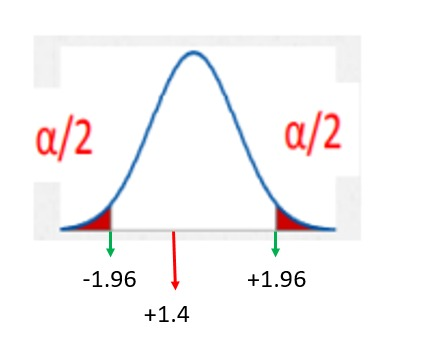

### Decisión

Como Zcalc = 1.40 no PERTENECE a la región sombreada, entonces no RECHAZO H0.

### Conclusión

Con el 0.05 de significación, hay evidencia para no rechazar H0 entonces se puede considerar que el promedio de tiempo es igual a 30 minutos.

### Hipótesis 4

En esta hipótesis planteamos si es que la velocidad promedio real calculado a través del speedtest es mayor igual a 50 MBPS. Para ello usaremos la prueba de t-student, unilateral izquierda, con una significancia de α = 0.05, para analizar si es que nuestra hipótesis cumple y hallar su rechazo también.

H0 : La velocidad promedio real medida a través de speedtest es mayor igual a 50.

H1 : La velocidad promedio real medida a través de speedtest es menor a 50

H0 : µ ≥ 50

H1 : µ < 50

```r
summary(Base$VEL_CAR_REAL)
```

```
##    Min. 1st Qu.  Median    Mean 3rd Qu.    Max.
##   10.37   33.95   85.73   87.08  110.42 1130.00
```

```r
sd(Base$VEL_CAR_REAL)
```

```
## [1] 99.82345
```

```r
dim(Base)
```

```
## [1] 152  26
```

```r
qnorm(0.05)
```

```
## [1] -1.644854
```

Como nuestra muestra es 152,o sea es mayor a 30, podemos utilizar el Z= 4.58

### Regiones Críticas

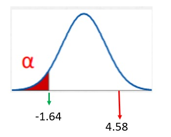

### Decisión

Como Zcalc = 4.58 NO PERTENECE a la región sombreada, entonces NO RECHAZO H0.

# 8. REFLEXIONES Y CONCLUSIONES

### 8.1. REFLEXIONES

- A lo largo de este trabajo hemos podido resolver muchas de nuestras dudas acerca de la calidad de conexión que se presenta en Lima, específicamente en 5 de los distritos de nuestra capital.
- Una de las principales interrogantes que planteamos fue si es que las empresas daban lo ofrecido a sus cliente, ahora podemos que en la gran mayoría de casos no es así, si bien hay excepciones, la mayoría de nuestros encuestados dijo que no recibían lo que les ofrecían.
- Además de ello, también podemos ver que el Internet hoy en día es muy importante en la vida de las personas, ya sea para el estudio, trabajo o relajación.
- Por otro lado, en los hogares es común que una familia use el internet simultáneamente, por ello es que también baja la velocidad de Internet.

### 8.2. CONCLUSIONES

- En conclusión, podemos decir que logramos el objetivo de analizar la calidad de conexión a Internet en 5 distritos de Lima, llegando así a decir que esta misma depende de muchos factores, como la cantidad de personas que lo usan, para que lo usan, el tiempo que es usado y desde dónde se usa. En términos generales se podría decir que la calidad es intermedia, y que varía depende de cada caso.

# FACTIBILIDAD

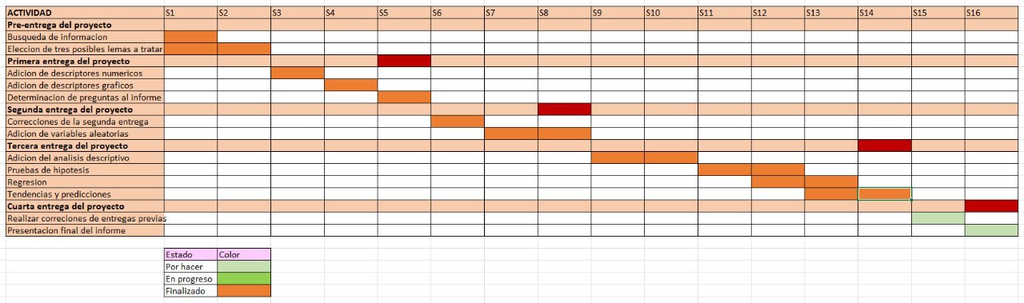